# Differential expressed gene (DEG) report (RNA-Seq) by RNASeqDEPipeline

Created Time: Sun Jul 22 17:21:17 2012

## Table of contents

1. Alignment (Tophat)
2. DEG by Cuffdiff
3. DEG analysis in R
   1. Estimate count level expression
   2. DEG detection by DESeq, edgeR and baySeq
   3. Significant DEG overlaps among different methods
4. Session Info

## 1. Alignment (Tophat)

**[TopHat](http://tophat.cbcb.umd.edu/)** is a fast splice junction mapper for RNA-Seq reads. It aligns RNA-Seq reads to mammalian-sized genomes using the ultra high-throughput short read aligner **[Bowtie](http://bowtie-bio.sourceforge.net/index.shtml)**, and then analyzes the mapping results to identify splice junctions between exons.

**Running Time**: 00:05:07:49

**Running Code**:

```r
tophat -p 8  -o tophat/kidneylane4 /home/lij17/accre/gpfs20/data/cqs/guoy1/reference/hg19/bowtie_index/hg19 /2TB/projects/RNA-Seq/normalization/data/rna_normal/lane/kidney1.5pm_run2_lane4.txt
tophat -p 8  -o tophat/kidneylane8 /home/lij17/accre/gpfs20/data/cqs/guoy1/reference/hg19/bowtie_index/hg19 /2TB/projects/RNA-Seq/normalization/data/rna_normal/lane/kidney1.5pm_run2_lane8.txt
tophat -p 8  -o tophat/liverlane1 /home/lij17/accre/gpfs20/data/cqs/guoy1/reference/hg19/bowtie_index/hg19 /2TB/projects/RNA-Seq/normalization/data/rna_normal/lane/liver1.5pm_run2_lane1.txt
tophat -p 8  -o tophat/liverlane7 /home/lij17/accre/gpfs20/data/cqs/guoy1/reference/hg19/bowtie_index/hg19 /2TB/projects/RNA-Seq/normalization/data/rna_normal/lane/liver1.5pm_run2_lane7.txt
```

## 2. DEG by Cuffdiff

**cuffdiff** tests for differential expression and is part of **[cufflinks](http://cufflinks.cbcb.umd.edu/)** which assembles transcripts, estimates their abundances, and tests for differential expression and regulation in RNA-Seq samples.

**Result Files**

1. Differentially expressed genes
2. Differentially expressed transcriprts

**Running Time**: 00:00:04:48

**Running Code**:

```r
cuffdiff --upper-quartile-norm -p 8  -o DE/cuffdiff /home/lij17/accre/gpfs20/data/cqs/guoy1/reference/annotation/hg19/Homo_sapiens.GRCh37.63_protein_coding_chr1-22-X-Y-M.gtf tophat/kidneylane4/accepted_hits.bam,tophat/kidneylane8/accepted_hits.bam  tophat/liverlane1/accepted_hits.bam,tophat/liverlane7/accepted_hits.bam
```

## 3. Differential gene expression in R

### 3.1 Estimate count level expression

**Result Files**

1. Gene count table
2. Transcriprt count table

**Running Code**:

```r
# For parallel
suppressPackageStartupMessages(library(multicore))
# Functions defined to calculate count level data for gene/transcript
source("/home/lij17/Dropbox/Documents/RNA-Seq/RNASeqDEPipeline/bam2count.R")
## parameters

## bamfiles are sorted by groups
bamfiles <- c("tophat/kidneylane8/accepted_hits.bam", "tophat/kidneylane4/accepted_hits.bam",
    "tophat/liverlane1/accepted_hits.bam", "tophat/liverlane7/accepted_hits.bam")
names(bamfiles) <- c("kidneylane8", "kidneylane4", "liverlane1", "liverlane7")
gtffile <- "/home/lij17/accre/gpfs20/data/cqs/guoy1/reference/annotation/hg19/Homo_sapiens.GRCh37.63_protein_coding_chr1-22-X-Y-M.gtf"
threads <- 2
logfile <- "run.log"
geneoutput <- "DE/R/gene_expr_count.csv"
transcriptoutput <- "DE/R/transcript_expr_count.csv"

# Step 1) load gtf
write.log(msg = "Load GTF file...", file = logfile)
system.time(gr <- gtf2GRangesList(myfile = gtffile))
```

```
##    user  system elapsed
## 188.836   0.964 190.185
```

```r
# Step 2) Loop bamfiles, get count level for both gene and transcript
write.log(msg = "Start to get count level expression from bamfiles", file = logfile)
system.time(count.list <- mclapply(bamfiles, function(f) {
    write.log(msg = paste("Getting count levele expression from file '", f,
        "'", sep = ""), file = logfile)
    aln = readBamGappedAlignments(f)
    r <- mclapply(gr, function(x) {
        getCounts(aln, grangelist = x)
    }, mc.cores = 2)
}, mc.cores = threads))
```

```
##    user  system elapsed
##  90.085   7.536  81.243
```

```r
gene.count <- sapply(count.list, function(x) x$gene)
transcript.count <- sapply(count.list, function(x) x$transcript)

# Step 3) Write out result
write.log(msg = "Write out count level data into files", file = logfile)
write.csv(gene.count, file = geneoutput)
write.csv(transcript.count, file = transcriptoutput)
```

### 3.2 Differential gene expression by DESeq, edgeR, baySeq and TSPM

**Method brief description**

1. **DESeq** – Simon Anders, Wolfgang Huber: Differential expression analysis for sequence count data. Genome Biology 11 (2010) R106, [doi:10.1186/gb-2010-11-10-r106](http://dx.doi.org/10.1186/gb-2010-11-10-r106)/ [R package at bioconductor](http://bioconductor.org/packages/release/bioc/html/DESeq.html)
2. **edgeR** – Robinson MD, McCarthy DJ, Smyth GK: edgeR: a Bioconductor package for differential expression analysis of digital gene expression data. Bioinformatics (2010), [doi:10.1093/bioinformatics/btp616](http://dx.crossref.org/10.1093%2Fbioinformatics%2Fbtp616) / [R package at bioconductor](http://bioconductor.org/packages/release/bioc/html/edgeR.html)
3. **baySeq** – Thomas J Hardcastle, Krystyna A Kelly: baySeq: Empirical Bayesian methods for identifying differential expression in sequence count data. BMC Bioinformatics (2010), [doi:10.1186/1471-2105-11-422](http://dx.doi.org/10.1186/1471-2105-11-422) / [R package at bioconductor](http://bioconductor.org/packages/release/bioc/html/baySeq.html)
4. **TSPM** – Paul L. Auer, Rebecca W. Doerge: A Two-Stage Poisson Model for Testing RNA-Seq Data. Statistical Applications in Genetics and Molecular Biology (2011), [doi: 10.2202/1544-6115.1627](http://dx.doi.org/10.2202/1544-6115.1627) / [R Code](http://www.stat.purdue.edu/%7Edoerge/software/TSPM.R)

**Result Files**

1. DE genes by R
2. DE transcriprts by R

**Running Code**:

```r
source("/home/lij17/Dropbox/Documents/RNA-Seq/RNASeqDEPipeline/DEUtil.R")
group <- c("1", "1", "2", "2")
mc.cores <- 4
degeneoutfile <- "DE/R/de_gene_expr_count.csv"
detranscriptoutfile <- "DE/R/de_transcript_expr_count.csv"

## Do differential gene expression
countData <- read.csv("DE/R/gene_expr_count.csv", row.names = 1)
system.time(wrapFourDE(countData, group, degeneoutfile, mc.cores = mc.cores))
```

```
##    user  system elapsed
## 121.620   9.369 319.182
```

```r
## Do differentail transcript expression
countData <- read.csv("DE/R/transcript_expr_count.csv", row.names = 1)
system.time(wrapFourDE(countData, group, detranscriptoutfile, mc.cores = mc.cores))
```

```
##     user   system  elapsed
##  471.789    6.476 1980.763
```

### 3.3 Significant DEG overlaps among different methods

This module lists all the significant genes and transcript among all the methods at FDR<=0.1  
**Result Files**

1. Overlapped DE genes among all the methods
2. Overlapped DE transcriprts among all the methods
3. All DE genes
4. All DE transcriprts

**Running Code**:

```r
source("/home/lij17/Dropbox/Documents/RNA-Seq/RNASeqDEPipeline/seeOverlaps.R")
# Overlapped DE genes
cuffdiffFile.gene <- "DE/cuffdiff/gene_exp.diff"
rdeFile.gene <- "DE/R/de_gene_expr_count.csv"
allDE.gene.output <- "DE/R/all_de_gene_expr_count.csv"
overlapDE.gene.output <- "DE/R/overlapped_de_gene_expr_count.csv"
system.time(seeOverlap(cuffdiffFile = cuffdiffFile.gene, rdeFile = rdeFile.gene,
    output.all = allDE.gene.output, output.overlap = overlapDE.gene.output,
    type = "genes"))
```

```
## There are 2913 overlapped genes among all the methods at FDR<=0.1
```

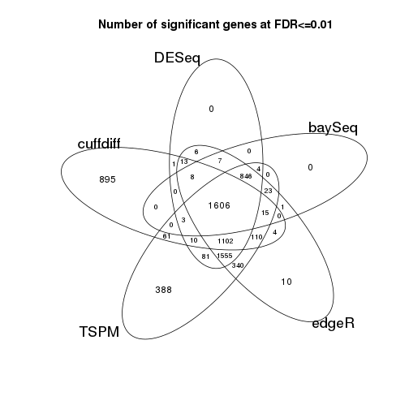

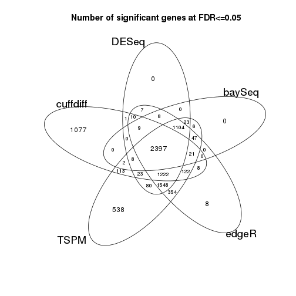

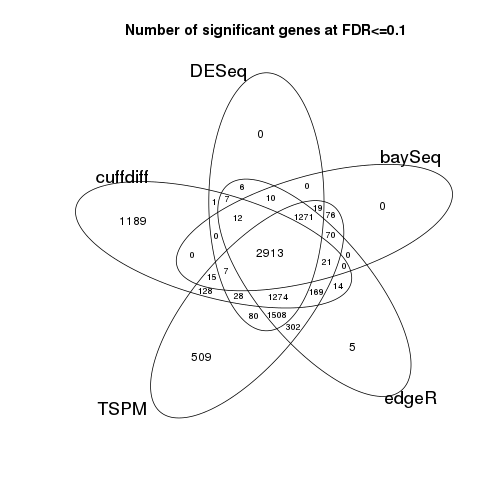

```
##    user  system elapsed
##   3.564   0.056   3.628
```

```r
# Overlapped DE transcript
cuffdiffFile.transcript <- "DE/cuffdiff/isoform_exp.diff"
rdeFile.transcript <- "DE/R/de_transcript_expr_count.csv"
allDE.transcript.output <- "DE/R/all_de_transcript_expr_count.csv"
overlapDE.transcript.output <- "DE/R/overlapped_de_transcript_expr_count.csv"
system.time(seeOverlap(cuffdiffFile = cuffdiffFile.transcript, rdeFile = rdeFile.transcript,
    output.all = allDE.transcript.output, output.overlap = overlapDE.transcript.output,
    type = "transcripts"))
```

```
## There are 4333 overlapped transcripts among all the methods at FDR<=0.1
```

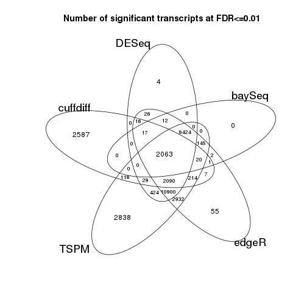

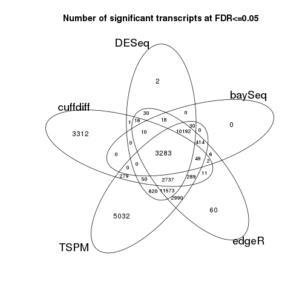

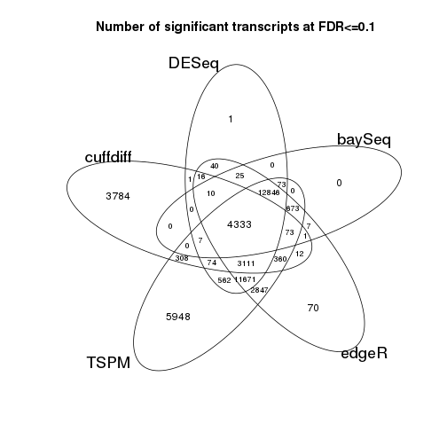

```
##    user  system elapsed
##  28.678   0.124  28.854
```

Produced by RNASeqDEPipeline (Jiang Li)